#Kira Plastinina customer behaviour analysis

## 1.Objective:

```
a.) Understanding Customer Behavior.
b.) Understanding the characteristics of customer groups.
```

## 2.Problem Statement.

#### Businesses in this day and time have learnt the power of leveraging data for product optimization and also to channel resources where they are needed. Unorthodox methods of marketing and assessing customer behavior based on gut feeling and guesses have led to losses in companies and also many have lost customers to companies that understand their customers in a deeper level.In this scope of analysis we will delve in understanding customer behavior and cluster them to groups for optimum product development through effective marketing strategies.

## 3.) Data Sourcing.

#### This data was sourced from kira Plastina’s ecommerce website as the product is sold through a chain of retail stores in Russia,Ukraine,Kazakhstan,Belarus,Chins,Philipines and Armenia.

## 4. Experimental Design

#### This scope of analysis will involve reviewing data to inspect its fittness to carry out analysis. This will later be followed by a deep analysis of the variables present in our data while understanding customers behaviour from these results. The solution will finaly be implemented by segemting the customers into similar clusters and reviewing the unique characteristics of these groups.

## 5.) Checking the data.

```r
# Viewing the data structures and its constituents
library(data.table)
customer_df<-fread("http://bit.ly/EcommerceCustomersDataset")
head(customer_df)
```

```
##    Administrative Administrative_Duration Informational Informational_Duration
## 1:              0                       0             0                      0
## 2:              0                       0             0                      0
## 3:              0                      -1             0                     -1
## 4:              0                       0             0                      0
## 5:              0                       0             0                      0
## 6:              0                       0             0                      0
##    ProductRelated ProductRelated_Duration BounceRates ExitRates PageValues
## 1:              1                0.000000  0.20000000 0.2000000          0
## 2:              2               64.000000  0.00000000 0.1000000          0
## 3:              1               -1.000000  0.20000000 0.2000000          0
## 4:              2                2.666667  0.05000000 0.1400000          0
## 5:             10              627.500000  0.02000000 0.0500000          0
## 6:             19              154.216667  0.01578947 0.0245614          0
##    SpecialDay Month OperatingSystems Browser Region TrafficType
## 1:          0   Feb                1       1      1           1
## 2:          0   Feb                2       2      1           2
## 3:          0   Feb                4       1      9           3
## 4:          0   Feb                3       2      2           4
## 5:          0   Feb                3       3      1           4
## 6:          0   Feb                2       2      1           3
##          VisitorType Weekend Revenue
## 1: Returning_Visitor   FALSE   FALSE
## 2: Returning_Visitor   FALSE   FALSE
## 3: Returning_Visitor   FALSE   FALSE
## 4: Returning_Visitor   FALSE   FALSE
## 5: Returning_Visitor    TRUE   FALSE
## 6: Returning_Visitor   FALSE   FALSE
```

```r
# The data is comprised of 10 numerical and 8 categorical variables. In them contains the nature of their operation in the e commerce website.
```

```r
str(customer_df)
```

```
## Classes 'data.table' and 'data.frame':   12330 obs. of  18 variables:
##  $ Administrative         : int  0 0 0 0 0 0 0 1 0 0 ...
##  $ Administrative_Duration: num  0 0 -1 0 0 0 -1 -1 0 0 ...
##  $ Informational          : int  0 0 0 0 0 0 0 0 0 0 ...
##  $ Informational_Duration : num  0 0 -1 0 0 0 -1 -1 0 0 ...
##  $ ProductRelated         : int  1 2 1 2 10 19 1 1 2 3 ...
##  $ ProductRelated_Duration: num  0 64 -1 2.67 627.5 ...
##  $ BounceRates            : num  0.2 0 0.2 0.05 0.02 ...
##  $ ExitRates              : num  0.2 0.1 0.2 0.14 0.05 ...
##  $ PageValues             : num  0 0 0 0 0 0 0 0 0 0 ...
##  $ SpecialDay             : num  0 0 0 0 0 0 0.4 0 0.8 0.4 ...
##  $ Month                  : chr  "Feb" "Feb" "Feb" "Feb" ...
##  $ OperatingSystems       : int  1 2 4 3 3 2 2 1 2 2 ...
##  $ Browser                : int  1 2 1 2 3 2 4 2 2 4 ...
##  $ Region                 : int  1 1 9 2 1 1 3 1 2 1 ...
##  $ TrafficType            : int  1 2 3 4 4 3 3 5 3 2 ...
##  $ VisitorType            : chr  "Returning_Visitor" "Returning_Visitor" "Returning_Visitor" "Returning_Visitor" ...
##  $ Weekend                : logi  FALSE FALSE FALSE FALSE TRUE FALSE ...
##  $ Revenue                : logi  FALSE FALSE FALSE FALSE FALSE FALSE ...
##  - attr(*, ".internal.selfref")=<externalptr>
```

```r
# Checking the dimension of my dataset
dim(customer_df)
```

```
## [1] 12330    18
```

```r
# My dataset has 12330 rows and 18 columns.
```

## 6.) Cleaning data

### Duplicated values

```r
# Duplicated values
length(which(duplicated.data.frame(customer_df)))
```

```
## [1] 119
```

```r
# 119 rows are duplicated
```

```r
# Dealing with duplicated rows
customer_df<-customer_df[!duplicated(customer_df),]
head(customer_df)
```

```
##    Administrative Administrative_Duration Informational Informational_Duration
## 1:              0                       0             0                      0
## 2:              0                       0             0                      0
## 3:              0                      -1             0                     -1
## 4:              0                       0             0                      0
## 5:              0                       0             0                      0
## 6:              0                       0             0                      0
##    ProductRelated ProductRelated_Duration BounceRates ExitRates PageValues
## 1:              1                0.000000  0.20000000 0.2000000          0
## 2:              2               64.000000  0.00000000 0.1000000          0
## 3:              1               -1.000000  0.20000000 0.2000000          0
## 4:              2                2.666667  0.05000000 0.1400000          0
## 5:             10              627.500000  0.02000000 0.0500000          0
## 6:             19              154.216667  0.01578947 0.0245614          0
##    SpecialDay Month OperatingSystems Browser Region TrafficType
## 1:          0   Feb                1       1      1           1
## 2:          0   Feb                2       2      1           2
## 3:          0   Feb                4       1      9           3
## 4:          0   Feb                3       2      2           4
## 5:          0   Feb                3       3      1           4
## 6:          0   Feb                2       2      1           3
##          VisitorType Weekend Revenue
## 1: Returning_Visitor   FALSE   FALSE
## 2: Returning_Visitor   FALSE   FALSE
## 3: Returning_Visitor   FALSE   FALSE
## 4: Returning_Visitor   FALSE   FALSE
## 5: Returning_Visitor    TRUE   FALSE
## 6: Returning_Visitor   FALSE   FALSE
```

```r
# Confirming the operation
length(which(duplicated.data.frame(customer_df)))
```

```
## [1] 0
```

```r
# No duplicated values present
```

## Missing values

```r
# Checking for missing values
length(which(is.na.data.frame(customer_df)))
```

```
## [1] 96
```

```r
# We have 96 missing values
```

Checking specific columns with the missing values

```r
# Checking the  missing number count
customer_df[!complete.cases(customer_df),]
```

```
##     Administrative Administrative_Duration Informational Informational_Duration
##  1:             NA                      NA            NA                     NA
##  2:             NA                      NA            NA                     NA
##  3:             NA                      NA            NA                     NA
##  4:             NA                      NA            NA                     NA
##  5:             NA                      NA            NA                     NA
##  6:             NA                      NA            NA                     NA
##  7:             NA                      NA            NA                     NA
##  8:             NA                      NA            NA                     NA
##  9:             NA                      NA            NA                     NA
## 10:             NA                      NA            NA                     NA
## 11:             NA                      NA            NA                     NA
## 12:             NA                      NA            NA                     NA
##     ProductRelated ProductRelated_Duration BounceRates ExitRates PageValues
##  1:             NA                      NA          NA        NA          0
```

[output cut: 37 more lines]

```r
# the are quite a lot to get rid off and they carry much data involving site information
```

#### Using the mice function to get a better understanding of missing data.

```r
library(mice)
```

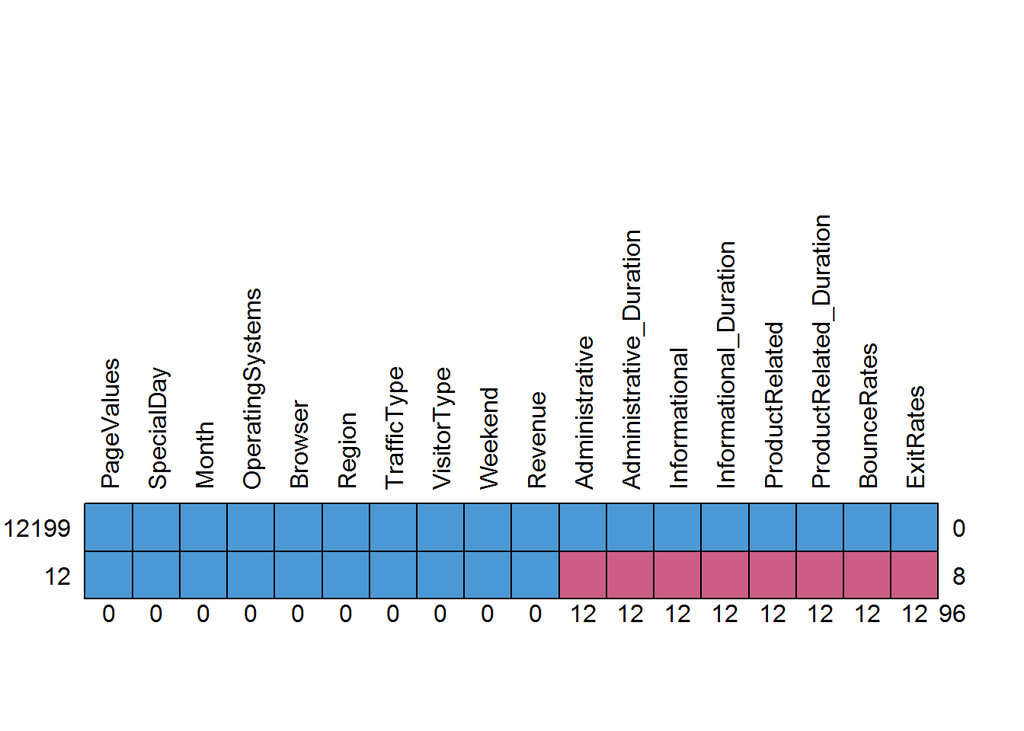

```
##       PageValues SpecialDay Month OperatingSystems Browser Region TrafficType
## 12199          1          1     1                1       1      1           1
## 12             1          1     1                1       1      1           1
##                0          0     0                0       0      0           0
##       VisitorType Weekend Revenue Administrative Administrative_Duration
## 12199           1       1       1              1                       1
## 12              1       1       1              0                       0
##                 0       0       0             12                      12
##       Informational Informational_Duration ProductRelated
## 12199             1                      1              1
## 12                0                      0              0
##                  12                     12             12
##       ProductRelated_Duration BounceRates ExitRates
## 12199                       1           1         1  0
## 12                          0           0         0  8
##                            12          12        12 96
```

```r
md.pattern(customer_df,plot = TRUE,rotate.names = TRUE)
```

```r
# We get to understand that there are a total of 96 missing values in the dataset and they are mainly found in the administrative,Informational,product related ,bounce rates and exit rates sites. Their proportions also are similar in magnitude.
```

Imputing them using the mice function

```r
# Assessing the imputation methods for mice
methods(mice)
```

```
##  [1] mice.impute.2l.bin       mice.impute.2l.lmer      mice.impute.2l.norm
##  [4] mice.impute.2l.pan       mice.impute.2lonly.mean  mice.impute.2lonly.norm
##  [7] mice.impute.2lonly.pmm   mice.impute.cart         mice.impute.jomoImpute
## [10] mice.impute.lda          mice.impute.logreg       mice.impute.logreg.boot
## [13] mice.impute.mean         mice.impute.midastouch   mice.impute.mnar.logreg
## [16] mice.impute.mnar.norm    mice.impute.norm         mice.impute.norm.boot
## [19] mice.impute.norm.nob     mice.impute.norm.predict mice.impute.panImpute
## [22] mice.impute.passive      mice.impute.pmm          mice.impute.polr
## [25] mice.impute.polyreg      mice.impute.quadratic    mice.impute.rf
## [28] mice.impute.ri           mice.impute.sample       mice.mids
## [31] mice.theme
## see '?methods' for accessing help and source code
```

Imputing using the mice function

```r
# Using random forest as the imputation method as most of our missing values are discrete
customer_df_full<-mice(customer_df,m=5,
                       method="rf",
                       maxit = 10,seed = 500)
# Getting a summary of the full set
summary(customer_df_full)
```

```
## Class: mids
## Number of multiple imputations:  5
## Imputation methods:
##          Administrative Administrative_Duration           Informational
##                    "rf"                    "rf"                    "rf"
##  Informational_Duration          ProductRelated ProductRelated_Duration
##                    "rf"                    "rf"                    "rf"
##             BounceRates               ExitRates              PageValues
##                    "rf"                    "rf"                      ""
##              SpecialDay                   Month        OperatingSystems
##                      ""                      ""                      ""
##                 Browser                  Region             TrafficType
##                      ""                      ""                      ""
##             VisitorType                 Weekend                 Revenue
##                      ""                      ""                      ""
## PredictorMatrix:
##                         Administrative Administrative_Duration Informational
## Administrative                       0                       1             1
## Administrative_Duration              1                       0             1
## Informational                        1                       1             0
## Informational_Duration               1                       1             1
## ProductRelated                       1                       1             1
## ProductRelated_Duration              1                       1             1
##                         Informational_Duration ProductRelated
## Administrative                               1              1
## Administrative_Duration                      1              1
## Informational                                1              1
## Informational_Duration                       0              1
## ProductRelated                               1              0
## ProductRelated_Duration                      1              1
##                         ProductRelated_Duration BounceRates ExitRates
## Administrative                                1           1         1
## Administrative_Duration                       1           1         1
## Informational                                 1           1         1
## Informational_Duration                        1           1         1
## ProductRelated                                1           1         1
## ProductRelated_Duration                       0           1         1
##                         PageValues SpecialDay Month OperatingSystems Browser
## Administrative                   1          1     0                1       1
## Administrative_Duration          1          1     0                1       1
## Informational                    1          1     0                1       1
## Informational_Duration           1          1     0                1       1
## ProductRelated                   1          1     0                1       1
## ProductRelated_Duration          1          1     0                1       1
##                         Region TrafficType VisitorType Weekend Revenue
## Administrative               1           1           0       1       1
## Administrative_Duration      1           1           0       1       1
## Informational                1           1           0       1       1
## Informational_Duration       1           1           0       1       1
## ProductRelated               1           1           0       1       1
## ProductRelated_Duration      1           1           0       1       1
## Number of logged events:  2
##   it im dep     meth         out
## 1  0  0     constant       Month
## 2  0  0     constant VisitorType
```

```r
# The imputation was successful with five complete data sets using random forest method.
```

# Getting the first dataset and visualizing the imputed values against my observed values to check for plausibility of the imputations

```r
complete_df<-complete(customer_df_full,1)
# Checking for missing values
length(which(is.na.data.frame(complete_df)))
```

```
## [1] 0
```

```r
# No missing value present
```

```r
table(complete_df$Administrative)
```

```
##
##    0    1    2    3    4    5    6    7    8    9   10   11   12   13   14   15
## 5647 1355 1114  915  766  575  432  338  287  225  153  105   86   56   44   38
##   16   17   18   19   20   21   22   23   24   26   27
##   24   16   12    6    2    2    4    3    4    1    1
```

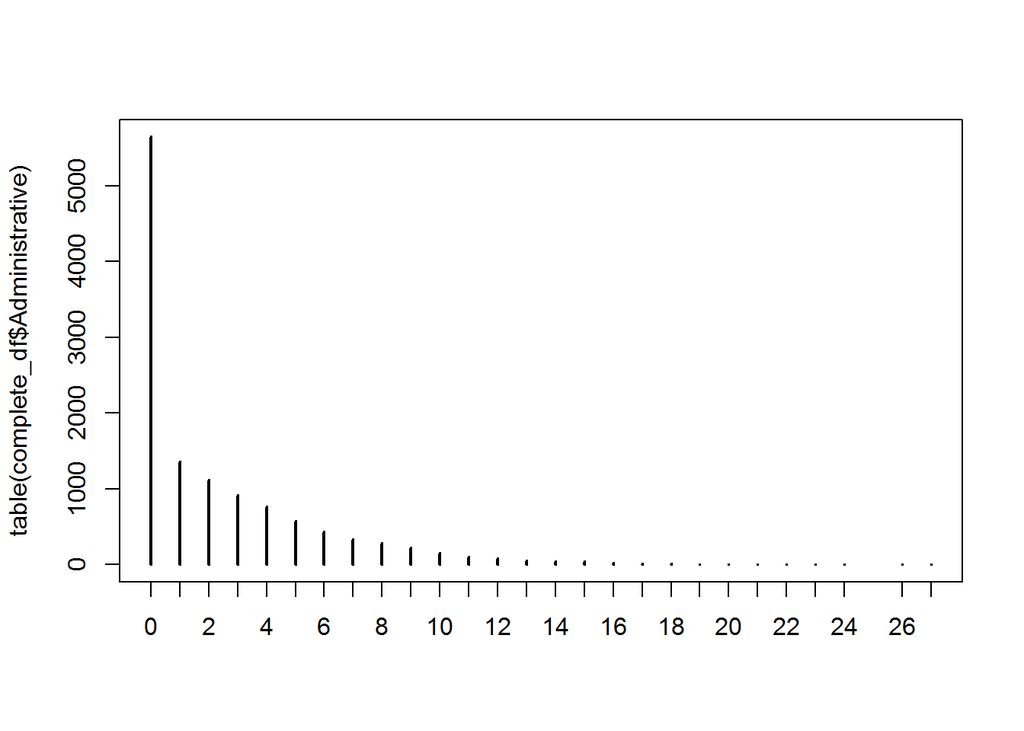

```r
plot(table(complete_df$Administrative))
```

```r
# Checking the unique values of distinct values in the original table with missing values
original<-customer_df$Administrative
# Checking the imputed values
customer_df_full$imp$Administrative
```

```
##      1 2 3 4 5
## 1050 0 3 0 0 1
## 1116 0 1 1 2 0
## 1117 4 0 2 0 0
## 1118 0 0 1 0 0
## 1119 0 0 0 0 4
## 1443 0 0 0 0 0
## 1444 0 0 0 0 0
## 1445 0 0 0 0 0
## 1446 0 0 0 0 0
## 1996 0 0 0 0 0
## 1997 1 0 0 0 0
## 2706 0 0 0 0 0
```

```r
# Checking the new value
imputed<-complete_df$Administrative
```

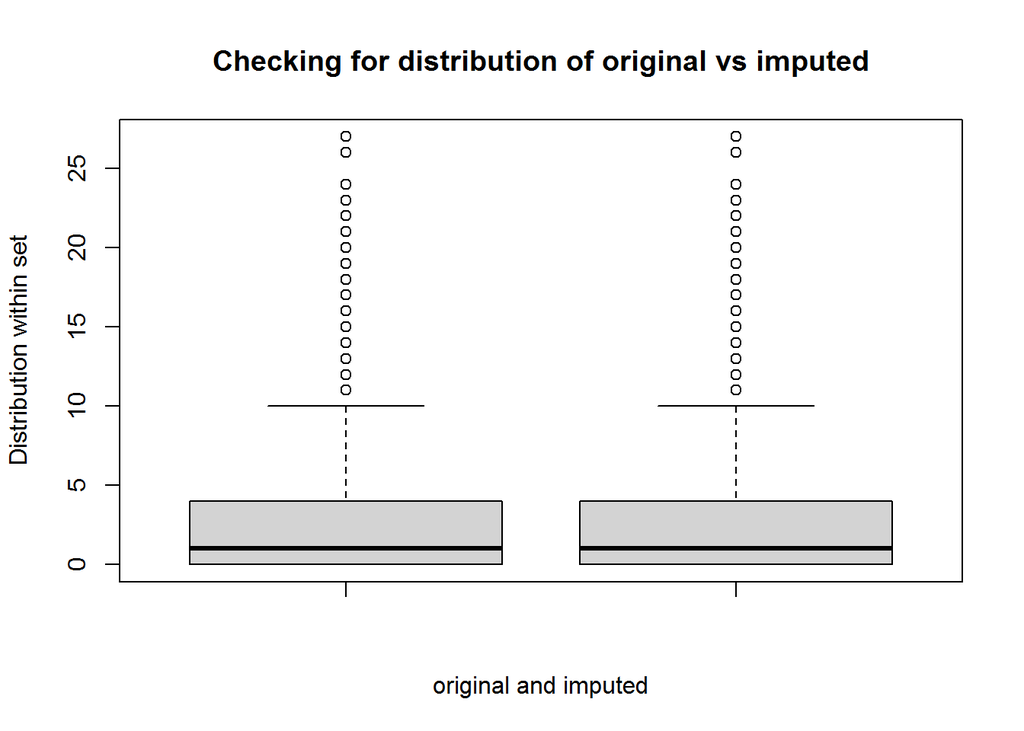

```r
boxplot(original,imputed,main="Checking for distribution of original vs imputed",xlab="original and imputed",ylab="Distribution within set")
```

```r
# The distribution is similar, that confirms the plausibility of the imputed values
```

```r
# Checking the unique values of distinct values in the original table with missing values
original_ex<-customer_df$ExitRates
# Checking the imputed values
customer_df_full$imp$ExitRates
```

```
##               1          2          3           4          5
## 1050 0.20000000 0.01176471 0.20000000 0.025000000 0.03287281
## 1116 0.20000000 0.04000000 0.00000000 0.009090909 0.01666667
## 1117 0.00952381 0.01818182 0.05000000 0.022222222 0.02500000
## 1118 0.03600000 0.04166667 0.03333333 0.100000000 0.02000000
## 1119 0.06500000 0.05777778 0.20000000 0.034074074 0.02571429
## 1443 0.02500000 0.02222222 0.10000000 0.040000000 0.10000000
## 1444 0.01777778 0.10000000 0.10000000 0.008333333 0.04000000
## 1445 0.06666667 0.06666667 0.02500000 0.007407407 0.06666667
## 1446 0.01666667 0.03750000 0.20000000 0.100000000 0.05000000
## 1996 0.20000000 0.13194444 0.03333333 0.200000000 0.00000000
## 1997 0.10000000 0.04000000 0.03333333 0.008695652 0.20000000
## 2706 0.01666667 0.04000000 0.06666667 0.075000000 0.06666667
```

```r
# Checking the new value
imputed_ex<-complete_df$ExitRates
```

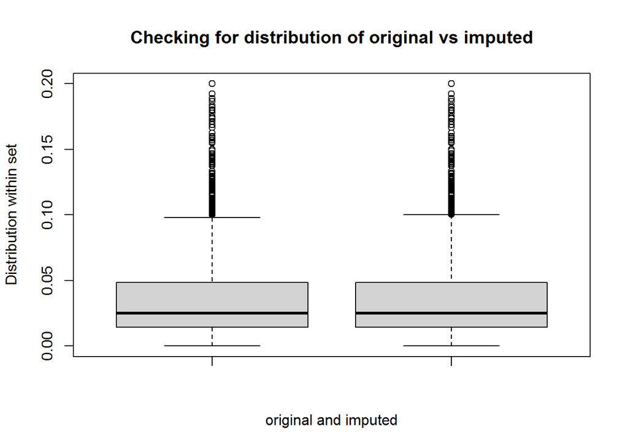

```r
# Checking the distribution between the original with null values and the imputed values to check for similarity
boxplot(original_ex,imputed_ex,main="Checking for distribution of original vs imputed",xlab="original and imputed",ylab="Distribution within set")
```

### Checking for Outliers and anomalies

```r
# Rechecking the clean and complete dataset
head(complete_df)
```

```
##   Administrative Administrative_Duration Informational Informational_Duration
## 1              0                       0             0                      0
## 2              0                       0             0                      0
## 3              0                      -1             0                     -1
## 4              0                       0             0                      0
## 5              0                       0             0                      0
## 6              0                       0             0                      0
##   ProductRelated ProductRelated_Duration BounceRates ExitRates PageValues
## 1              1                0.000000  0.20000000 0.2000000          0
## 2              2               64.000000  0.00000000 0.1000000          0
## 3              1               -1.000000  0.20000000 0.2000000          0
## 4              2                2.666667  0.05000000 0.1400000          0
## 5             10              627.500000  0.02000000 0.0500000          0
## 6             19              154.216667  0.01578947 0.0245614          0
##   SpecialDay Month OperatingSystems Browser Region TrafficType
## 1          0   Feb                1       1      1           1
## 2          0   Feb                2       2      1           2
## 3          0   Feb                4       1      9           3
## 4          0   Feb                3       2      2           4
## 5          0   Feb                3       3      1           4
## 6          0   Feb                2       2      1           3
##         VisitorType Weekend Revenue
## 1 Returning_Visitor   FALSE   FALSE
## 2 Returning_Visitor   FALSE   FALSE
## 3 Returning_Visitor   FALSE   FALSE
## 4 Returning_Visitor   FALSE   FALSE
## 5 Returning_Visitor    TRUE   FALSE
## 6 Returning_Visitor   FALSE   FALSE
```

### Numerical varables

```r
# Rechecking numeric datatypes
str(complete_df)
```

```
## 'data.frame':    12211 obs. of  18 variables:
##  $ Administrative         : int  0 0 0 0 0 0 0 1 0 0 ...
##  $ Administrative_Duration: num  0 0 -1 0 0 0 -1 -1 0 0 ...
##  $ Informational          : int  0 0 0 0 0 0 0 0 0 0 ...
##  $ Informational_Duration : num  0 0 -1 0 0 0 -1 -1 0 0 ...
##  $ ProductRelated         : int  1 2 1 2 10 19 1 1 2 3 ...
##  $ ProductRelated_Duration: num  0 64 -1 2.67 627.5 ...
##  $ BounceRates            : num  0.2 0 0.2 0.05 0.02 ...
##  $ ExitRates              : num  0.2 0.1 0.2 0.14 0.05 ...
##  $ PageValues             : num  0 0 0 0 0 0 0 0 0 0 ...
##  $ SpecialDay             : num  0 0 0 0 0 0 0.4 0 0.8 0.4 ...
##  $ Month                  : chr  "Feb" "Feb" "Feb" "Feb" ...
##  $ OperatingSystems       : int  1 2 4 3 3 2 2 1 2 2 ...
##  $ Browser                : int  1 2 1 2 3 2 4 2 2 4 ...
##  $ Region                 : int  1 1 9 2 1 1 3 1 2 1 ...
##  $ TrafficType            : int  1 2 3 4 4 3 3 5 3 2 ...
##  $ VisitorType            : chr  "Returning_Visitor" "Returning_Visitor" "Returning_Visitor" "Returning_Visitor" ...
##  $ Weekend                : logi  FALSE FALSE FALSE FALSE TRUE FALSE ...
##  $ Revenue                : logi  FALSE FALSE FALSE FALSE FALSE FALSE ...
```

### A function to plot a box plot for numerical values and detect outliers

```r
# Boxplot of the individual variables
box_plot<-function(data,var,main){
  boxplot(data[[var]],ylab="Distribution of values",main=main)
}
```

#### a.)

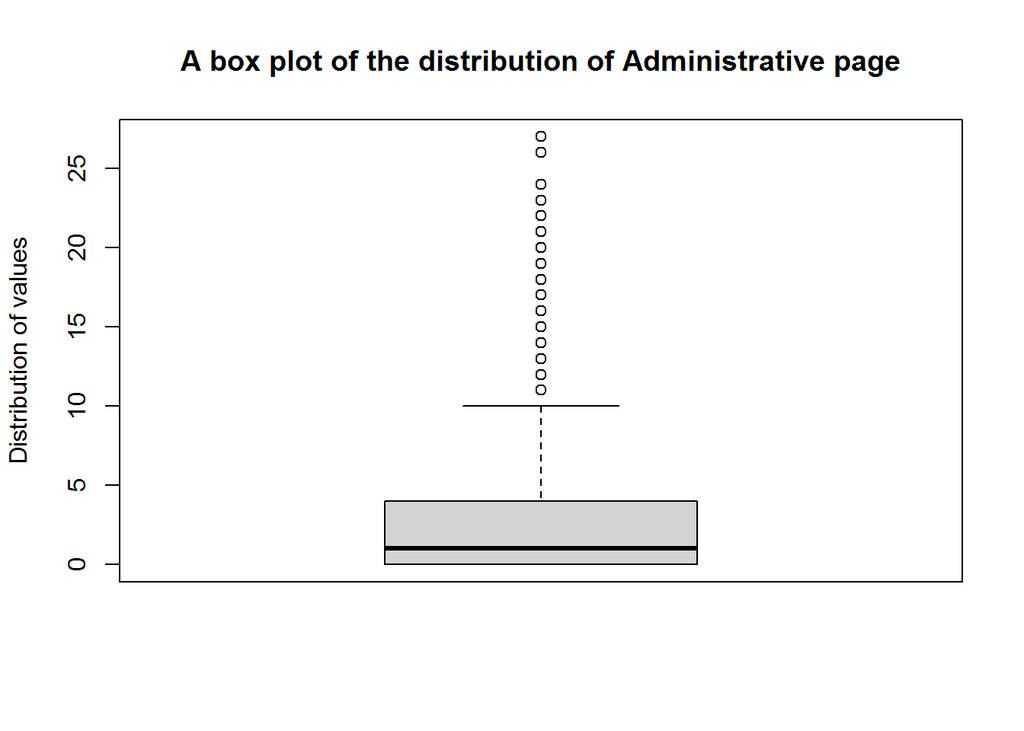

```r
#  A box plot of Administrative distribution
box_plot(complete_df,1,"A box plot of the distribution of Administrative page")
```

```r
# This represent the number of administrative pages visited by a visited in that session.
# Most customers visited less than 5 administrative sites. It is also possible for them to visit more than 25 pages . This set wont be treated as an outlier. Users if this page could be actual administrators and maybe customers.
```